# Google Data Analytics Capstone project

## Determining the number of rides by membership per week

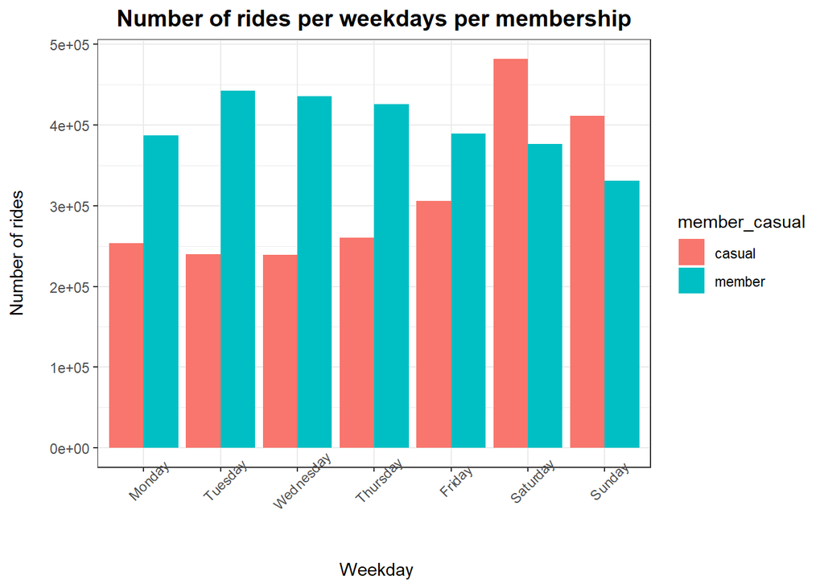

```r
# determining the ride length by membership per week
ride_length_per_membership<-cyclic_data4 %>%
  group_by(member_casual,day_of_week) %>%
  summarise(average_ride_length = mean(ride_length_minutes),
            number_of_rides = n())

# representing with the number of rides per week days
ggplot(ride_length_per_membership,aes(x = day_of_week, y=number_of_rides, fill = member_casual))+geom_col(position = "dodge")+labs(title="Number of rides per weekdays per membership", x = "\n Weekday", y = "Number of rides\n")+theme_bw()+
  theme(axis.text.x = element_text(angle = 45),
        plot.title = element_text(size = 14, hjust = 0.5, face = "bold"))
```

```r
# the graph clearly shows that we have more casual members on weekend
```

## representing the average ride length in minutes per week days

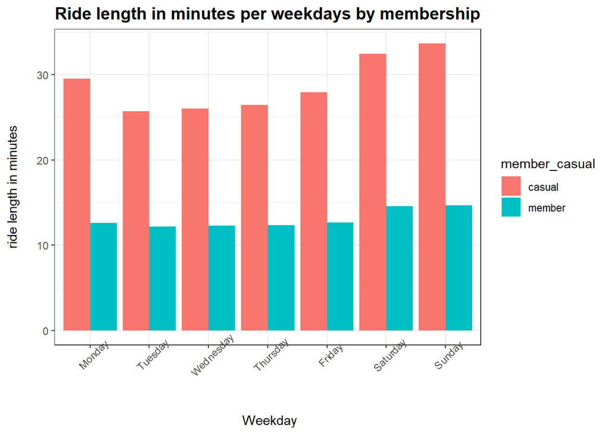

```r
ggplot(ride_length_per_membership,aes(x = day_of_week, y= average_ride_length, fill = member_casual))+geom_col(position = "dodge")+labs(title="Ride length in minutes per weekdays by membership", x = "\n Weekday", y = "ride length in minutes\n")+theme_bw()+
  theme(axis.text.x = element_text(angle = 45),
        plot.title = element_text(size = 14, hjust = 0.5, face = "bold"))
```

```r
#the graph shows that the average ridelength per week for casual riders is higher than that of members
```

## determing the number of rides per month

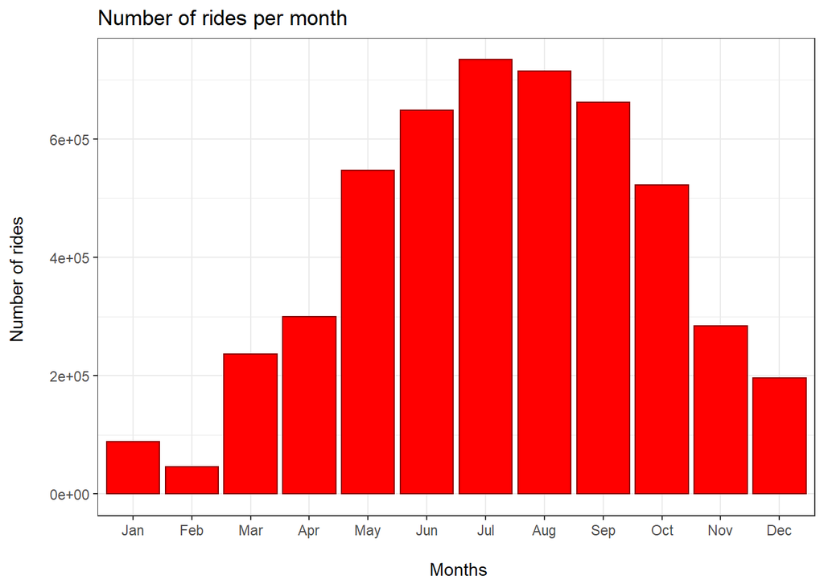

```r
#ride length per month
ride_length_per_month_only<-cyclic_data4 %>%
  group_by(month) %>%
  summarise(average_ride_length = mean(ride_length_minutes),
            tot_ride_length = sum(ride_length_minutes),
            number_of_rides = n())

# representing the number of rides per month
ggplot(ride_length_per_month_only,aes(x = month, y = number_of_rides ))+geom_col(position="dodge",color = "darkred", fill = "red")+ labs(title = "Number of rides per month", x ="\n Months", y = "Number of rides \n") +guides(fill =guide_legend(title = "Membership"))+theme_bw()
```

```r
# the graph shows that the months of June to september have the highest number of rides
```

## ride length per membership per month

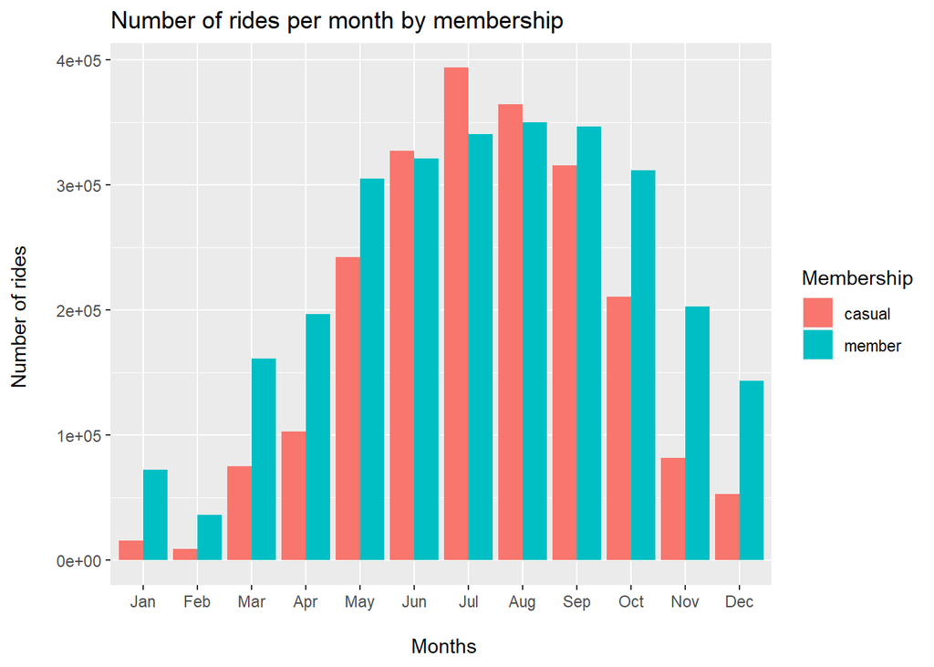

```r
ride_length_per_month<-cyclic_data4 %>%
  group_by(member_casual,month) %>%
  summarise(average_ride_length = mean(ride_length_minutes),
            tot_ride_length = sum(ride_length_minutes),
            number_of_rides = n())

# representing the number of rides per membership per month
ggplot(ride_length_per_month,aes(x = month, y = number_of_rides, fill = member_casual))+geom_col(position="dodge")+ labs(title = "Number of rides per month by membership", x ="\n Months", y = "Number of rides \n") +guides(fill =guide_legend(title = "Membership"))
```

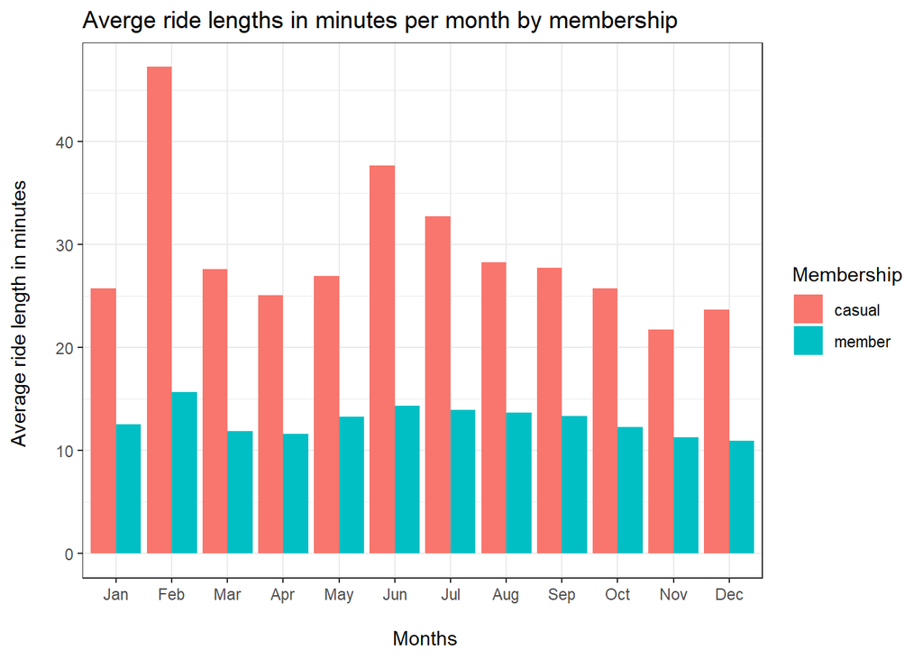

```r
# representing the average ride length per membership per month
ggplot(ride_length_per_month,aes(x = month, y = average_ride_length, fill = member_casual))+geom_col(position="dodge")+ labs(title = "Averge ride lengths in minutes per month by membership", x ="\n Months", y = "Average ride length in minutes \n") +guides(fill =guide_legend(title = "Membership"))+ theme_bw()
```

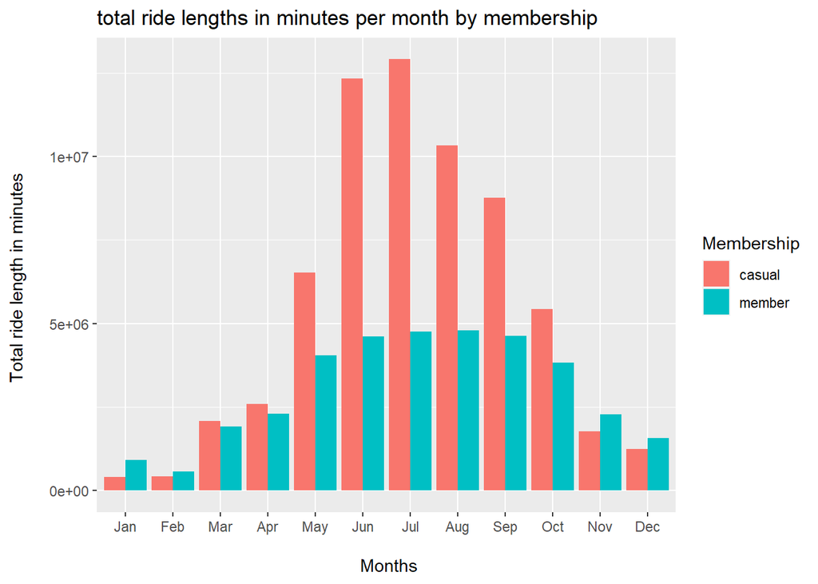

```r
# representing the total ride length per month
ggplot(ride_length_per_month,aes(x = month, y = tot_ride_length, fill = member_casual))+geom_col(position="dodge")+ labs(title = "total ride lengths in minutes per month by membership", x ="\n Months", y = "Total ride length in minutes \n") +guides(fill =guide_legend(title = "Membership"))
```

```r
# The first graph shows something surprising, casual riders have the highest number of rides from of june to august
# The second graphs shows that casual riders have the highest average riding time per month throughout the year i.e have more riding time
# The third graph shows that the number of casual riders have the highest total riding time from march to august
```

# Finding the number of rides per starting hours each week per membership. This will help identify at what time riders are the most active

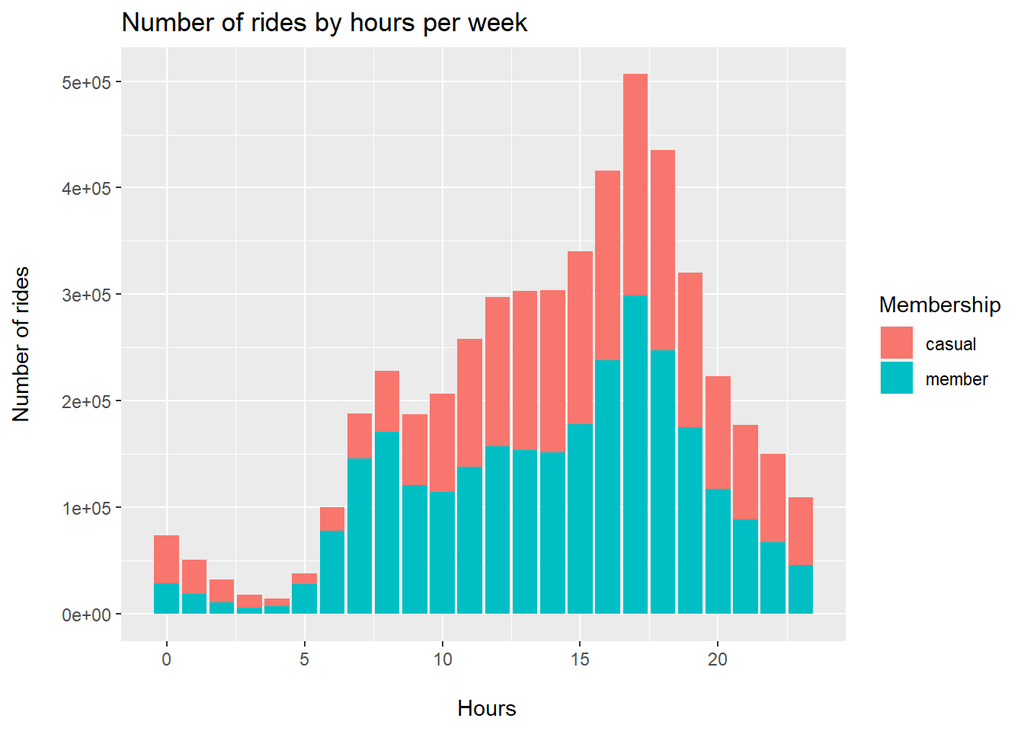

```r
# finding the number of rides by starting hours by week per membership
bike_rides_week_hours<-cyclic_data4 %>% group_by(day_of_week,start_hour,member_casual) %>%
  summarise(
    Minutes_total = sum(ride_length_minutes),
    Average = mean(ride_length_minutes),
    number_of_rides = n()
  ) %>% ungroup()

# representing the number of rides by hours
ggplot(bike_rides_week_hours, aes(x = start_hour, y =number_of_rides, fill = member_casual))+geom_col() + labs(title = "Number of rides by hours per week", x ="\n Hours", y="Number of rides\n" )+ guides(fill =guide_legend(title = "Membership"))
```

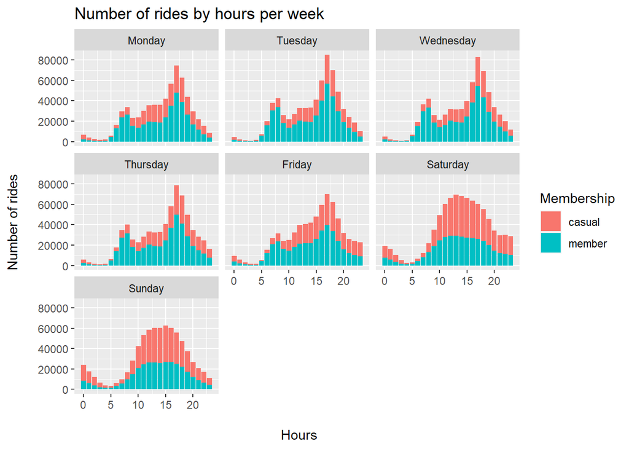

```r
# representing the Number of rides by hours for each day of the week by membership
ggplot(bike_rides_week_hours, aes(x = start_hour, y =number_of_rides, fill = member_casual))+geom_col() + labs(title = "Number of rides by hours per week", x ="\n Hours", y="Number of rides\n" )+facet_wrap(~day_of_week)+guides(fill =guide_legend(title = "Membership"))
```

```r
# First graph shows that riders are most active between 12pm and 8pm for both casual and active riders
# The second graph shows clear differences in pattern between weekdays and weekends. interesting! on weekends there is more activity between 9 am and 8pm. WHy? this requires more investigation.
```

# Finding the number of rides by starting hours by month per memberships

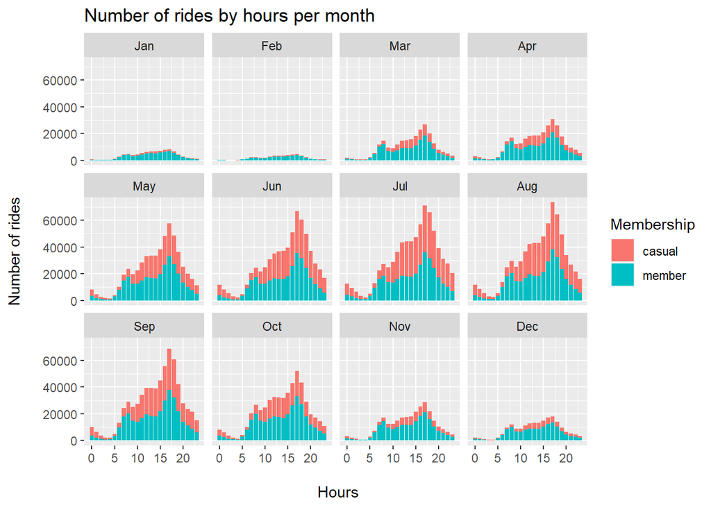

```r
# number of rides by starting hours by month per membership
bike_rides_month_hours<-cyclic_data4 %>% group_by(month,start_hour,member_casual) %>%
  summarise(
    Minutes_total = sum(ride_length_minutes),
    Average = mean(ride_length_minutes),
    number_of_rides = n()
  ) %>% ungroup()

# representing the Number of rides by hours per month by membership
ggplot(bike_rides_month_hours, aes(x = start_hour, y =number_of_rides, fill = member_casual))+geom_col() + labs(title = "Number of rides by hours per month", x ="\n Hours", y="Number of rides\n" )+facet_wrap(~month)+guides(fill =guide_legend(title = "Membership"))
```

# Finding the most popular bike types per weekday for each membership type

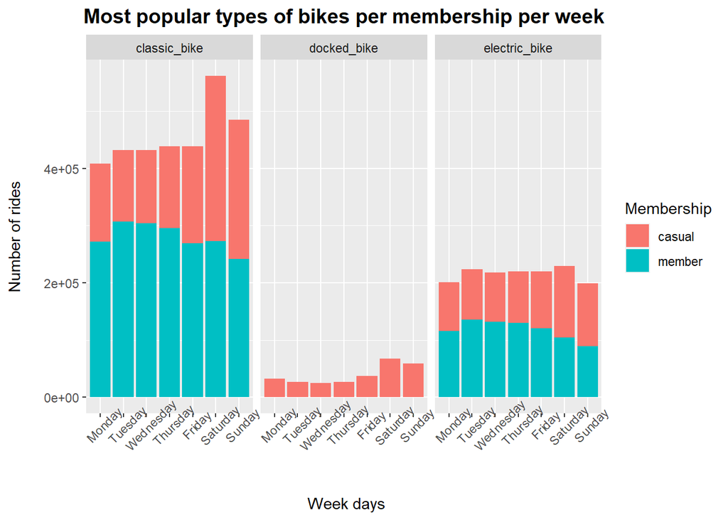

```r
# Finding the most popular bike types per week for each membership
bike_type_week<-cyclic_data4 %>% group_by(day_of_week,rideable_type,member_casual) %>%
  summarise(
    Minutes_total = sum(ride_length_minutes),
    Mean = mean(ride_length_minutes),
    number_of_rides = n()
  ) %>% ungroup()

# representing the most popular bike types per week for each memberships
ggplot(bike_type_week,aes(x = day_of_week,y= number_of_rides, fill = member_casual)) + geom_col()+facet_wrap(~rideable_type)+labs(title ="Most popular types of bikes per membership per week", x = "\n Week days", y = "Number of rides\n")+guides(fill =guide_legend(title = "Membership"))+
  theme(axis.text.x = element_text(angle = 45),
        plot.title = element_text(size = 14, hjust = 0.5, face = "bold"))
```

```r
# the data shows clearly that docked_bike types are the least favorite bike types while the most favorite one is classic bike follwed by electric bike.
```

# Finding the most popular bike types per memberships

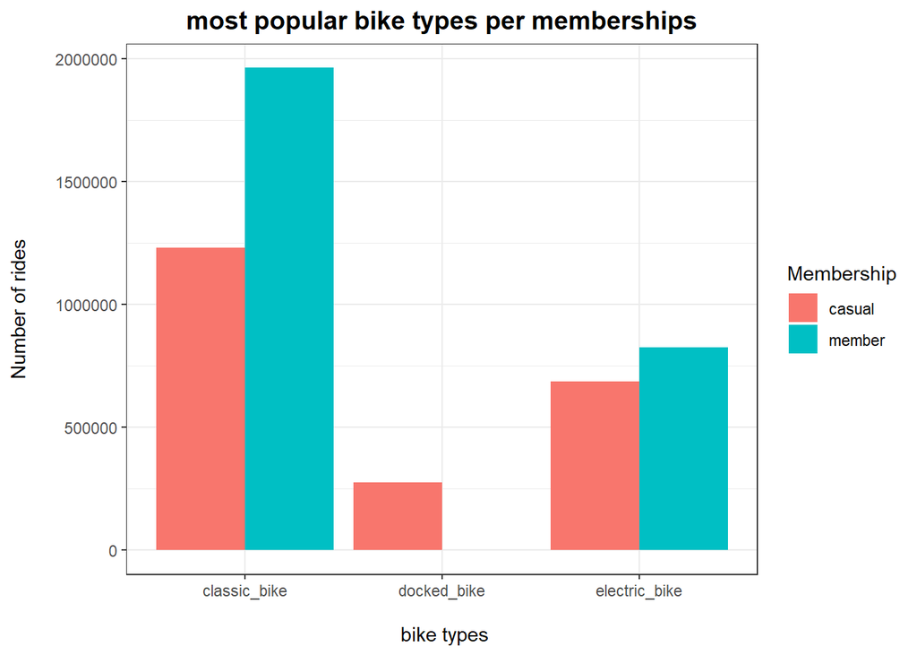

```r
# Finding the most popular bike types per memberships
bike_type<-cyclic_data4 %>% group_by(rideable_type,member_casual) %>%
  summarise(
    Minutes_total = sum(ride_length_minutes),
    average_ride_time = mean(ride_length_minutes),
    number_of_rides = n()
  ) %>% ungroup()

# representing the most popular bike types per memberships
ggplot(bike_type, aes(x=rideable_type, y =number_of_rides, fill=member_casual,))+geom_col(position = "dodge")+labs(title = "most popular bike types per memberships", x = "\n bike types", y = "Number of rides\n" )+guides(fill =guide_legend(title = "Membership"))+
  theme_bw()+
  theme(axis.text.x = element_text(angle = 0),
        plot.title = element_text(size = 14, hjust = 0.5, face = "bold"))
```

#Finding out who rides more on days of the week and weekend for each membership type

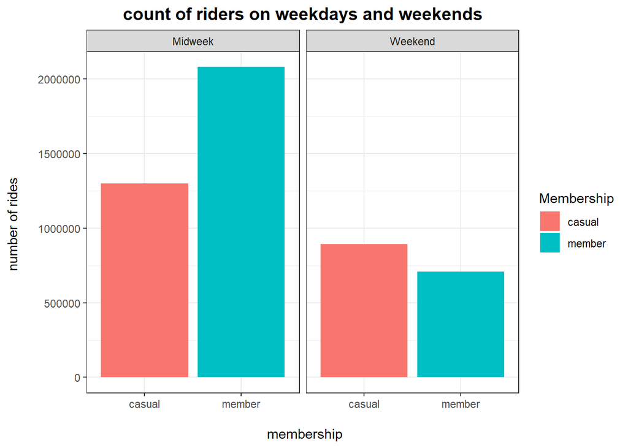

```r
# finding out who rides more on days of the week and weekend by memberships
more<-cyclic_data4 %>% group_by(member_casual,day_of_week) %>%
  summarise(
    average_ride_length = mean(ride_length_minutes),
    number_of_rides = n()
  ) %>% ungroup()

more<-more %>% mutate(type_of_week = ifelse(day_of_week == "Saturday"| day_of_week == "Sunday", "Weekend", "Midweek"))

ggplot(more, aes(x = member_casual, y = number_of_rides, fill = member_casual))+ geom_col()+ labs(title = "count of riders on weekdays and weekends", x = "\n membership", y ="number of rides \n")+ facet_wrap(~type_of_week)+guides(fill =guide_legend(title = "Membership"))+
  theme_bw()+
  theme(axis.text.x = element_text(angle = 0),
        plot.title = element_text(size = 14, hjust = 0.5, face = "bold"))
```

#finding the percentage of bike types, ride length, number of rides, average ride length and total ride length

```r
# finding the mmost popular biketypes
bike_type_month<-cyclic_data4 %>% group_by(rideable_type) %>%
  summarise(
    Minutes_total = sum(ride_length_minutes),
    average_ride_time = mean(ride_length_minutes),
    number_of_rides = n()) %>% ungroup %>%
  mutate(total= sum(number_of_rides),
         percentage = (number_of_rides/total) *100)
print(bike_type_month)
```

```
## # A tibble: 3 x 6
##   rideable_type Minutes_total average_ride_ti~ number_of_rides  total percentage
##   <chr>                 <dbl>            <dbl>           <int>  <int>      <dbl>
## 1 classic_bike      58039001.             18.2         3195374 4.98e6      64.2
## 2 docked_bike       19723922.             71.8          274640 4.98e6       5.51
## 3 electric_bike     23248823.             15.4         1511028 4.98e6      30.3
```

```r
#
```

# Finding the most start stations

```r
# finding the top stations(i.e start and end stations)
length(unique(cyclic_data4$start_station_name))
```

```
## [1] 1107
```

```r
length(unique(cyclic_data4$start_station_id))
```

```
## [1] 1061
```

```r
# finding the most busiest stations per memberships
bike_stations<-cyclic_data4 %>% group_by(start_station_name) %>%
  summarise(
    Minutes_total = sum(ride_length_minutes),
    average_ride_length = mean(ride_length_minutes),
   number_of_rides = n()
  ) %>% ungroup() %>% arrange(desc(number_of_rides))

#selecting the top 10 rides

top_stations<-head(bike_stations, n= 10)
print(top_stations)
```

```
## # A tibble: 10 x 4
##    start_station_name       Minutes_total average_ride_length number_of_rides
##    <chr>                            <dbl>               <dbl>           <int>
##  1 Streeter Dr & Grand Ave       3178277.                37.9           83906
##  2 Michigan Ave & Oak St         1469026.                33.5           43907
##  3 Wells St & Concord Ln          682002.                15.6           43692
##  4 Millennium Park               1803409.                44.0           40991
##  5 Clark St & Elm St              689890.                16.9           40750
##  6 Wells St & Elm St              522255.                14.0           37320
##  7 Theater on the Lake            999586.                27.8           35988
##  8 Kingsbury St & Kinzie St       411637.                11.7           35046
##  9 Clark St & Armitage Ave        618734.                18.7           33066
## 10 Clark St & Lincoln Ave         616208.                18.8           32785
```

# finding the coordinates of the top stations to be represented in tableau

```r
#finding their appropriate coordinates to be represented in tableau by merging cyclic_data4 and topstations

popular_stations<-left_join(top_stations,cyclic_data4,by = "start_station_name") %>% arrange(desc(number_of_rides)) %>% group_by(start_station_name) %>% distinct(start_station_name, .keep_all = TRUE)

print(popular_stations)
```

```
## # A tibble: 10 x 25
## # Groups:   start_station_name [10]
##    start_station_name  Minutes_total average_ride_len~ number_of_rides ride_id
##    <chr>                       <dbl>             <dbl>           <int> <chr>
##  1 Streeter Dr & Gran~      3178277.              37.9           83906 E8CAB30E~
##  2 Michigan Ave & Oak~      1469026.              33.5           43907 C0C5C878~
##  3 Wells St & Concord~       682002.              15.6           43692 25C6DB0D~
##  4 Millennium Park          1803409.              44.0           40991 5516B65A~
##  5 Clark St & Elm St         689890.              16.9           40750 01CDE887~
##  6 Wells St & Elm St         522255.              14.0           37320 EEA541FD~
##  7 Theater on the Lake       999586.              27.8           35988 3D59FF0F~
##  8 Kingsbury St & Kin~       411637.              11.7           35046 B0909889~
##  9 Clark St & Armitag~       618734.              18.7           33066 5F216B9D~
## 10 Clark St & Lincoln~       616208.              18.8           32785 F08DEBCB~
## # ... with 20 more variables: rideable_type <chr>, started_at <dttm>,
## #   ended_at <dttm>, start_station_id <chr>, end_station_name <chr>,
## #   end_station_id <chr>, start_lat <dbl>, start_lng <dbl>, end_lat <dbl>,
## #   end_lng <dbl>, member_casual <chr>, date <date>, month <fct>, day <chr>,
## #   year <chr>, day_of_week <fct>, day_of_week_2 <dbl>, start_hour <int>,
## #   end_hour <int>, ride_length_minutes <dbl>
```

```r
# saving
# write_csv(popular_stations,"./popular_stations.csv")
```

# finding the most prefered routes

```r
cyclic_data4$routes<- paste(cyclic_data4$start_station_name,"to", cyclic_data4$end_station_name)

length(unique(cyclic_data4$routes))
```

```
## [1] 161804
```

```r
#showing the top routes
top_routes<-cyclic_data4 %>%group_by(routes) %>% summarise(
  Minutes_total = sum(ride_length_minutes),
  average_ride_length = mean(ride_length_minutes),
  number_of_rides =n()) %>% arrange(desc(number_of_rides)) %>% ungroup()

head(top_routes,n =10)
```

```
## # A tibble: 10 x 4
##    routes                        Minutes_total average_ride_len~ number_of_rides
##    <chr>                                 <dbl>             <dbl>           <int>
##  1 Streeter Dr & Grand Ave to S~       571201.             44.2            12934
##  2 Michigan Ave & Oak St to Mic~       296638.             47.8             6201
##  3 Ellis Ave & 60th St to Ellis~        37624.              6.36            5913
##  4 Ellis Ave & 60th St to Unive~        33295.              5.84            5702
##  5 Millennium Park to Millenniu~       241872.             44.2             5470
##  6 DuSable Lake Shore Dr & Monr~       208964.             38.8             5391
##  7 Ellis Ave & 55th St to Ellis~        33884.              6.38            5313
##  8 University Ave & 57th St to ~        27948.              5.28            5294
##  9 DuSable Lake Shore Dr & Monr~       123031.             28.8             4276
## 10 Streeter Dr & Grand Ave to M~       126419.             33.9             3726
```

# Act:

## The marketing team should focus on the 10 top stations presented here. During this period and offer weekly and monthy membership schemes should be offered.

## Also reducing the membership fees a little might be a good marketing strategy to gain more active members.

## the marketing campaign could be advertising on popular social media platforms and streamin services like facebook, instagram, twitter, youtube, netflix, amazon prime.

## Posters can be made in this period and posted at strategic venues like near train stations, popular shopping malls etc

## the data also shows that the most popular bike type is classic bike with 64%%, followed by electric bikes with 30% and docked type with 5%

## A recommendation is that further analysis needs to be carried out to investigate what causes the increase in the number of casual riders from June to august. A possible reason might because it is summer and the weather is sunny. I suggest carrying out a correlation analysis.